# Сканирование параметров

Имитационное моделирование

Автор

принадлежность

Mehmet Efe Kantoz, DSc

Российский университет дружбы народов

## Цель работы

Реализовать модель эпидемии SIR с использование сетей Петри[@RUDN_ESystem]

# Задание

- Создать рабочий каталог для кода.
- Установить необходимые пакеты.
- Выполнить предложенный код.
- Преобразовать код в литературный стиль.
- Сгенерировать из литературного кода:
  - чистый код;
  - jupyter notebook;
  - документацию в формате Quarto.
- Выполнить код из jupyter notebook.
- Интегрировать документацию в формате Quarto в отчёт.

## Задание (продолжение)

- Добавить в код в литературном стиле вычисление для набора параметров.
- Сгенерировать из литературного кода с параметрами:
  - чистый код;
  - jupyter notebook;
  - документацию в формате Quarto.
- Выполнить код из jupyter notebook с параметрами.
- Интегрировать документацию с параметрами в формате Quarto в отчёт.

# Теоретическое введение

## Описание модели

- S (восприимчивые) - могут заразиться;
- I (инфицированные) - заражают других и выздоравливают;
- R (выздоровевшие / с иммунитетом) - больше не участвуют в эпидемии.

## Построение сети Петри

- Функция: build_sir_network(β, γ)
- Создаёт размеченную сеть Петри (LabelledPetriNet) с двумя переходами:
  - infection: S + I -> I + I (скорость β)
  - recovery: I -> R (скорость γ)
- Возвращает:
  - объект сети net,
  - начальную маркировку u0 = [990.0, 10.0, 0.0],
  - имена состояний [:S, :I, :R].

## Детерминированная симуляция

- Функция: simulate_deterministic(net, u0, tspan; saveat, rates)
- Строит систему обыкновенных дифференциальных уравнений (ОДУ) на основе закона действующих масс.
- Решает её численно с помощью OrdinaryDiffEq (метод Tsit5).
- Возвращает DataFrame с колонками time, S, I, R.

## Стохастическая симуляция

- Файл: simulate_stochastic(net, u0, tspan; rates, rng)
- Используется алгоритм Гиллеспи.
- Реализует прямой метод Гиллеспи (SSA) для дискретных событий.
- На каждом шаге:
  - a_inf = β * S * I
  - a_rec = γ * I
- Случайным образом выбирает, произойдёт ли заражение или выздоровление, и через какое время.
- Возвращает DataFrame с временами и целочисленными маркировками.

## Вспомогательная функция ОДУ и Визуализация

**Вспомогательная функция ОДУ:** - Функция: sir_ode(net, rates) - Возвращает функцию правой части f!(du, u, p, t), которая используется в simulate_deterministic. - Сделана отдельно для гибкости.

**Визуализация:** - Функция: plot_sir(df) - Принимает DataFrame с колонками time, S, I, R и строит стандартный график динамики.

# Выполнение лабораторной работы

## Базовый прогон модели

Выполним один базовый эксперимент с фиксированными параметрами β = 0.3, γ = 0.1. Запустим два типа симуляции: Детерминированную и стохастическую.

[figure not shown]

Рисунок 1: Базовый прогон

## Запуск скрипта базового прогона

Запустим скрипт.

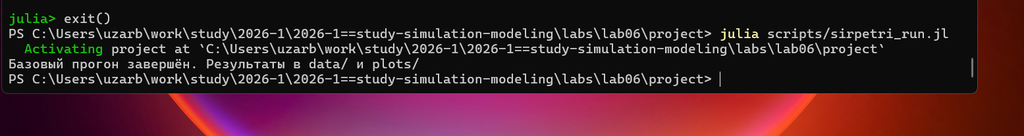

Рисунок 2: Запуск скрипта

## Создание производных форматов

Создадим все производные форматы.

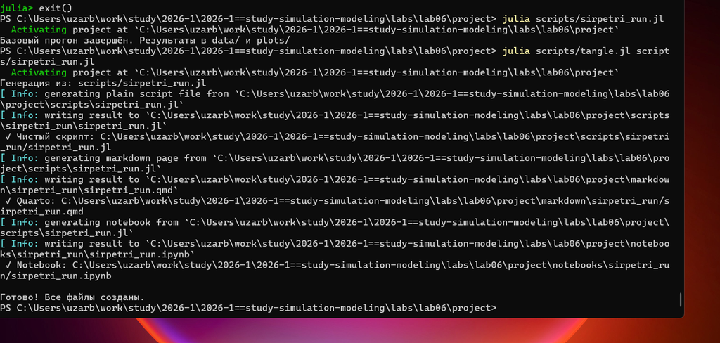

Рисунок 3: Создание форматов

## Запуск Jupyter Notebook

Запустим notebook файл.

[figure not shown]

Рисунок 4: Jupyter notebook

## Графики базового прогона

В результате получаем следующие графики (рис. 5, рис. 6).

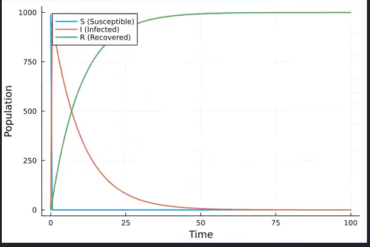

Рисунок 5: Детерминистический график динамики SIR

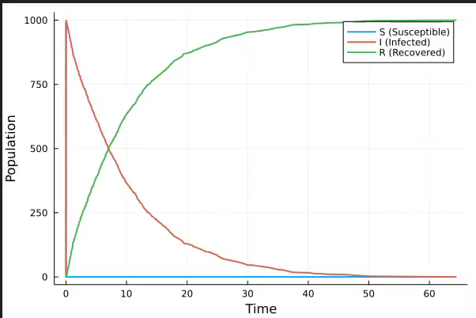

Рисунок 6: Стохастический график динамики SIR

## Код базового прогона

# 1. Ortam ve Paketlerin Yüklenmesi

using Pkg Pkg.activate(normpath(joinpath(@__DIR__, “../../..”))) using DrWatson @quickactivate “project”

using Random using DataFrames using CSV using Plots

include(srcdir(“SIRPetri.jl”)) using .SIRPetri

# 2. Параметры (Parametreler)

println(“Инициализация параметров…”) β = 0.3 γ = 0.1 tmax = 100.0

# 3. Создаём сеть (Ağ Oluşturma)

net, u0, states = build_sir_network(β, γ)

# 4. Детерминированная симуляция (Deterministik Simülasyon)

df_det = simulate_deterministic(net, u0, (0.0, tmax), saveat = 0.5, rates = [β, γ]) CSV.write(datadir(“sir_det.csv”), df_det)

# 5. Стохастическая симуляция (Stokastik Simülasyon)

Random.seed!(123) df_stoch = simulate_stochastic(net, u0, (0.0, tmax), rates = [β, γ]) CSV.write(datadir(“sir_stoch.csv”), df_stoch)

# 6. Графики (Grafikler ve Çizimler)

p_det = plot_sir(df_det) savefig(plotsdir(“sir_det_dynamics.png”))

p_stoch = plot_sir(df_stoch) savefig(plotsdir(“sir_stoch_dynamics.png”))

println(“Базовый прогон завершён. Результаты в data/ и plots/”)

## Исследование параметра β

Исследуем чувствительность модели к изменению параметра β (скорости заражения).

[figure not shown]

Рисунок 7: Исследование скорости заражения

## Запуск скрипта исследования

Запустим скрипт.

[figure not shown]

Рисунок 8: Запуск скрипта параметров

## Форматы и Notebook (β)

Создадим все производные форматы.

[figure not shown]

Рисунок 9: Форматы параметров

## Результат сканирования параметров

В результате получим следующий график.

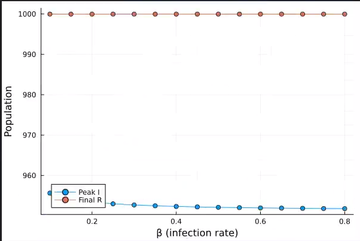

Рисунок 10: Коэффициент заражения β

## Код: сканирование параметров